# Econometrics Assignement 2- Brodard Lionel, Giro Tomas, Marchal Antoine, Schonenberger Ivan

——-> Please run this code with ‘Run all’ of *Ctrl+Alt+R*

# Question a) Generate the data: X, Y and epsilon

```r
## Parameters
alpha <- 0.5
beta_1 <- 0.8
beta_2 <- 1.3
real_beta <-rbind(alpha,beta_1,beta_2)
n <- 20
## Creation of the Matrix of X, the error term and calculation of Y
x_0 <- c(rep_len(1,n))
set.seed(12)
x_1 <- c(runif(n,0,10))
set.seed(1054)
x_2 <- c(runif(n,0,10))
set.seed(12)
X <- cbind(x_0,x_1,x_2)
eps <- c(rnorm(n,0,2))
Y <- alpha*x_0 + beta_1*x_1 + beta_2*x_2 + eps
message('X=')
```

```
X=
```

```r
round(X,1)
```

```
      x_0 x_1 x_2
 [1,]   1 0.7 9.9
 [2,]   1 8.2 3.9
 [3,]   1 9.4 4.5
 [4,]   1 2.7 4.4
 [5,]   1 1.7 4.6
 [6,]   1 0.3 2.5
 [7,]   1 1.8 8.3
 [8,]   1 6.4 3.0
 [9,]   1 0.2 4.0
[10,]   1 0.1 6.1
[11,]   1 3.9 3.2
[12,]   1 8.1 5.4
[13,]   1 3.8 3.4
[14,]   1 3.8 5.3
[15,]   1 2.6 8.9
[16,]   1 4.4 8.1
[17,]   1 4.6 8.7
[18,]   1 5.4 0.5
[19,]   1 6.7 3.8
[20,]   1 1.1 4.4
```

```r
message('Y=')
```

```
Y=
```

```r
round(Y,1)
```

```
 [1] 10.9 15.3 11.9  6.6  3.9  3.5 12.1  8.3  5.7  9.4  6.2 11.5  6.4 10.4 13.9
[16] 13.1 17.9  6.2 11.8  6.6
```

```r
message('epsilon=')
```

```
epsilon=
```

```r
round(eps,1)
```

```
 [1] -3.0  3.2 -1.9 -1.8 -4.0 -0.5 -0.6 -1.3 -0.2  0.9 -1.6 -2.6 -1.6  0.0 -0.3
[16] -1.4  2.4  0.7  1.0 -0.6
```

# Question b) Fit the model using OLS, estimate beta:

```r
est_B <- solve(t(X)%*%X)%*%t(X)%*%Y  # estimated beta
message('estimated beta=')
```

```
estimated beta=
```

```r
round(est_B,3)
```

```
      [,1]
x_0 -0.412
x_1  0.897
x_2  1.277
```

# Question c) Check two equations

```r
est_Y <- X%*%est_B #estimated Y
est_e <- Y-est_Y #residual error
# creation of equations that need to be tested
message('equation 1:')
```

```
equation 1:
```

```r
t(est_e)%*%est_e
```

```
         [,1]
[1,] 55.46452
```

```r
message('=')
t(Y)%*%Y-t(est_B)%*%t(X)%*%Y-t(Y)%*%X%*%est_B+t(est_B)%*%t(X)%*%X%*%est_B
```

```
         [,1]
[1,] 55.46452
```

```r
message('\nequation 2:')
```

```
equation 2:
```

```r
t(est_B)%*%t(X)%*%Y
```

```
         [,1]
[1,] 2075.362
```

```r
message('=')
t(Y)%*%X%*%est_B
```

```
         [,1]
[1,] 2075.362
```

# Question d) Check that the projection matrix P and the residual matrix M are symmetric and idempotent

```r
# compute matrix M
M <- diag(20)-X%*%solve(t(X)%*%X)%*%t(X)
message('max(abs(MM-M)) =')
```

```
max(abs(MM-M)) =
```

```r
max(abs(M%*%M-M))
```

```
[1] 2.220446e-16
```

```r
# compute matrix P -> P= Xinv(X'X)-X'
P <- X%*%solve(t(X)%*%X)%*%t(X)
message('\nmax(abs(PP-P)) =')
```

```
max(abs(PP-P)) =
```

```r
max(abs(P%*%P-P))
```

```
[1] 1.665335e-16
```

```r
message('\nmax(abs(P-t(P))) =')
```

```
max(abs(P-t(P))) =
```

```r
max(abs(P-t(P)))
```

```
[1] 1.804112e-16
```

```r
message('\nmax(abs(M-t(M))) =')
```

```
max(abs(M-t(M))) =
```

```r
max(abs(M-t(M)))
```

```
[1] 1.804112e-16
```

We can see that P and M are symmetric and idempotent.

# Question e) Using the same data sample, fit the simpler model which contains a constant and only the first regressor X1. Compute its SSE and compare it with the SSE of the full model.

```r
# partial model:
pX <- cbind(x_0,x_1) # pX stands for partial model X.
pest_B <- solve(t(pX)%*%pX)%*%t(pX)%*%Y
pest_Y <- pX%*%pest_B
pest_e <- Y-pest_Y
message('beta estimate of the partial model:')
```

```
beta estimate of the partial model:
```

```r
pest_B
```

```
         [,1]
x_0 7.1937328
x_1 0.6289826
```

```r
# SSE calculation
message('\nfull model SSE=')
```

```
full model SSE=
```

```r
fSSE <- t(est_e)%*%est_e
fSSE
```

```
         [,1]
[1,] 55.46452
```

```r
message('\npartial model SSE=')
```

```
partial model SSE=
```

```r
pSSE <- t(pest_e)%*%pest_e
pSSE
```

```
         [,1]
[1,] 232.8271
```

# Question f) Compute R2 and adjusted R2 of both models

```r
# R2 and ajusted R2 calculation
# SSR calculation est_Y-avY
# compute average of y
mean_Y <- c(rep_len(mean(Y),n))
# full model SSR
fSSR <- sum((est_Y-mean_Y)^2)
# partial model SSR
pSSR <- sum((pest_Y-mean_Y)^2)
# SST calculation
# SST
SST <- sum((Y-mean_Y)^2)
# R squared
fR2 <- 1-(fSSE/SST)
pR2 <- 1-(pSSE/SST)
# Adjusted-R squared = 1 - ((1-R2)(n-1)/(n-k-1)), where k= number of independant regressor
fk <- 2 # regressors of full model
pk <- 1 # regressors of partial model
fAR2 <- 1-((1-fR2)*(n-1)/(n-fk-1)) # adjusted r2 of full model
pAR2 <- 1-((1-pR2)*(n-1)/(n-pk-1)) # adjusted r2 of partial model
T1<-data.frame('type'='full model','R2'=fR2,'adjusted R2'=fAR2)
T2<-data.frame('type'='partial model', 'R2'=pR2,'adjusted R2'=pAR2)
T3=rbind(T1,T2)
print(T3)
```

|  | type | R2 | adjusted.R2 |
| --- | --- | --- | --- |
| 1 | full model | 0.8113342 | 0.7891382 |
| 2 | partial model | 0.2080251 | 0.1640265 |

Table of the R2s of the two models

# Question g) Generate a sample of size n=500 for the full model. Fit the full model on subsamples of the first 10, 20, 50, 100, 250, 500 simulated observations, which gives you a sequence of 6 estimates.

```r
# create a vector n for the 6 subsamples
n=cbind(10,20,50,100,250,500)
# generate a sample of X, errors of n6=500 and calculate the full model
X_500_0 <- c(rep_len(1,500))
set.seed(12)
X_500_1 <- c(runif(500,0,10))
set.seed(1054)
X_500_2 <- c(runif(500,0,10))
X_500 <- cbind(X_500_0,X_500_1,X_500_2)
set.seed(12)
Neps <- c(rnorm(500,0,2))
Y_new <- c(rep_len(1,500))
Y_new <- alpha*X_500_0 + beta_1*X_500_1 + beta_2*X_500_2 + Neps
# create a loop to calculate the estimated beta for each subsample
estimated_beta_full <-matrix(1,nrow=3,ncol = 6)
ee <-c(rep(1,6))
for (i in 1:6){
  X<-cbind(rep(1,n[i]),X_500_1[1:n[i]],X_500_2[1:n[i]])
  estimated_beta_full[1:3,i]<-solve(t(X)%*%X)%*%t(X)%*%Y_new[1:n[i]]
  e<-Y_new[1:n[i]]-X%*%estimated_beta_full[1:3,i]
  ee[i]<-t(e)%*%e
}
# We create a data frame df1 with the values of the estimators
df1=data.frame('n'=t(n),'alpha'=round(estimated_beta_full[1,],2),'beta 1'=round(estimated_beta_full[2,],2),'beta 2'=round(estimated_beta_full[3,],2))
# generate a NEW sample of X, compute the new data frame and plot the evolutions
sec_X_500_0 <- c(rep_len(1,500))
set.seed(14)
sec_X_500_1 <- c(runif(500,0,10))
set.seed(27)
sec_X_500_2 <- c(runif(500,0,10))
sec_X_500 <- cbind(sec_X_500_0,sec_X_500_1,sec_X_500_2)
set.seed(14)
sec_Neps <- c(rnorm(500,0,2))
sec_Y_new <- c(rep_len(1,500))
sec_Y_new <- alpha*sec_X_500_0 + beta_1*sec_X_500_1 + beta_2*sec_X_500_2 + sec_Neps
# create a loop to calculate the estimated beta for each subsample
sec_estimated_beta_full <-matrix(1,nrow=3,ncol = 6)
sec_ee <-c(rep(1,6))
for (i in 1:6){
  X<-cbind(rep(1,n[i]),sec_X_500_1[1:n[i]],sec_X_500_2[1:n[i]])
  sec_estimated_beta_full[1:3,i]<-solve(t(X)%*%X)%*%t(X)%*%sec_Y_new[1:n[i]]
  e<-sec_Y_new[1:n[i]]-X%*%sec_estimated_beta_full[1:3,i]
  ee[i]<-t(e)%*%e
}
df2=data.frame('n'=t(n),'alpha'=round(sec_estimated_beta_full[1,],2),'beta 1'=round(sec_estimated_beta_full[2,],2),'beta 2'=round(sec_estimated_beta_full[3,],2))
#plots:
with(df1,
     plot(n,
          alpha,
          type='l',
          ylim = c(min(c(df1$alpha,df2$alpha)),max(c(df1$alpha,df2$alpha)))))
lines(df2$n,
      df2$alpha,
      col='red')
```

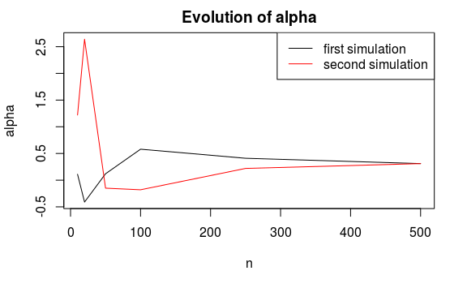

```r
legend("topright",
       legend=c("first simulation", "second simulation"),
       col=c("black", "red"), lty=c(1,1))
title('Evolution of alpha')
```

```r
with(df1,
     plot(n,
          beta.1,
          type='l',
          ylim = c(min(c(df1$beta.1,df2$beta.1)),max(c(df1$beta.1,df2$beta.1)))))
lines(df2$n,df2$beta.1, col='red')
```

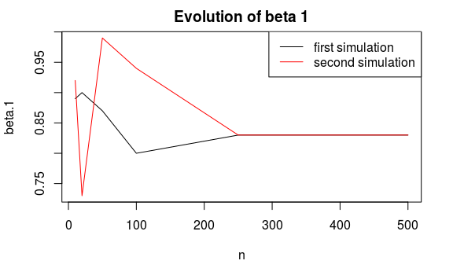

```r
legend("topright",
       legend=c("first simulation", "second simulation"),
       col=c("black", "red"), lty=c(1,1))
title('Evolution of beta 1')
```

```r
with(df1,
     plot(n,
          beta.2,
          type='l',
          ylim = c(min(c(df1$beta.2,df2$beta.2)),max(c(df1$beta.2,df2$beta.2)))))
lines(df2$n,df2$beta.2, col='red')
```

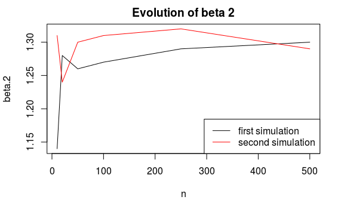

```r
legend("bottomright",
       legend=c("first simulation", "second simulation"),
       col=c("black", "red"), lty=c(1,1))
title('Evolution of beta 2')
```

```r
df1
```

| n | alpha | beta.1 | beta.2 |
| --- | --- | --- | --- |
| 10 | 0.11 | 0.89 | 1.14 |
| 20 | -0.41 | 0.90 | 1.28 |
| 50 | 0.12 | 0.87 | 1.26 |
| 100 | 0.58 | 0.80 | 1.27 |
| 250 | 0.41 | 0.83 | 1.29 |
| 500 | 0.31 | 0.83 | 1.30 |

```r
df2
```

| n | alpha | beta.1 | beta.2 |
| --- | --- | --- | --- |
| 10 | 1.22 | 0.92 | 1.31 |
| 20 | 2.64 | 0.73 | 1.24 |
| 50 | -0.15 | 0.99 | 1.30 |
| 100 | -0.18 | 0.94 | 1.31 |
| 250 | 0.22 | 0.83 | 1.32 |
| 500 | 0.31 | 0.83 | 1.29 |

# How do the estimates evolve as the sample size increases?

We can see in the different graphs of the evolution of the parameters that they converge.

# Generate another sample of the same size n=500 and compute the resulting sequence of 6 estimates.

# Do you obtain similar results?

As we can observe in the graphs we obtain similar results. Not only the evolutions converge, but they do to the same limits.